# Harris Student Government Finance Committee Transparency Report

### *Fall 2026*

## At a glance

Budget  
$20,000

Allocated  
$19,500

Total requested  
$72,067

HSOs that applied  
24

Events reviewed  
97

The Finance Committee of Harris Student Government (HSG) allocates funding to Harris Student Organizations (HSOs) each quarter. This report shows what every HSO asked for, what it received, and why, so any student can check the decisions. Requests this quarter totaled $72,067 against a $20,000 budget, so the committee could fund about 27% of what was asked. The remaining $500 goes to the Emergency Reserve, which is set aside for HSOs, including new HSOs that form during the year.

## Our approach

The HSG Finance Committee exists to help HSOs turn the diversity, curiosity, and creativity of the Keller Center into real impact. That includes culture, art, and civic engagement. Policy doesn’t happen in a vacuum. It grows out of how we work, study, and celebrate together.

- **Who it serves:** the specific community the event is designed for
- **What it aims to achieve:** its intended outcomes for that community
- **Why it matters:** how meaningfully it serves the people it’s built for

We score impact holistically, not by size alone. Events designed for smaller communities are valued just as much as large ones when they serve their audience well.

Our goal is to channel that creativity into tangible benefits for Harris students today and to build an open, curious, evidence-driven culture that carries forward to future cohorts.

## How funding works

Every allocation has two parts:

- **Flat share:** 25% of the budget is split equally among every HSO that applied on time, $208 each this quarter.
- **Flexible share:** the remaining $15,000 is split in proportion to each HSO’s **committee score × eligible request**.

**Eligible request** is what an HSO asked for, minus food spending above these limits:

| Event type | What it means | What HSG covers |
| --- | --- | --- |
| Cultural | The food or cultural practice *is* the event | All food |
| Programmatic | A speaker, panel, training or service event that would happen without food | Food up to 60% of the event budget |
| Social | The gathering itself is the point (mixers, pub nights, outings) | Up to $400 per event, times the number of confirmed co-hosting HSOs |

**Committee score** is the average of each reviewer’s score plus one automatic score computed from the application. Every reviewer scores three areas from 1 to 5, weighted 30% Financial Stewardship, 25% Collaboration & Inclusion and 45% Impact. Reviewers recuse themselves from HSOs they belong to.

**Rollover** is each HSO’s HarrisHub “Available” balance, and it counts toward the HSO’s events. An HSO can set part of it aside as an earmark when the money is restricted by a sponsor, donor or grant, committed under a signed contract, or saved for a specific event later in the academic year that the HSO itemizes with its cost. General savings don’t count.

See METHODOLOGY.md for a summary of the rules and formulas, and the [policy documents](https://github.com/A-Sarkar18/hsg-finance-transparency/tree/main/policy) for the full Fall 2026 policy.

No HSO can receive more than its flat share plus its eligible request, and allocations are rounded to the nearest $10. Any change the committee makes by hand is marked with a short note in the table at the end.

## Allocations

A few large requests drive most of the demand: the five largest requests made up 42% of all money requested this quarter.

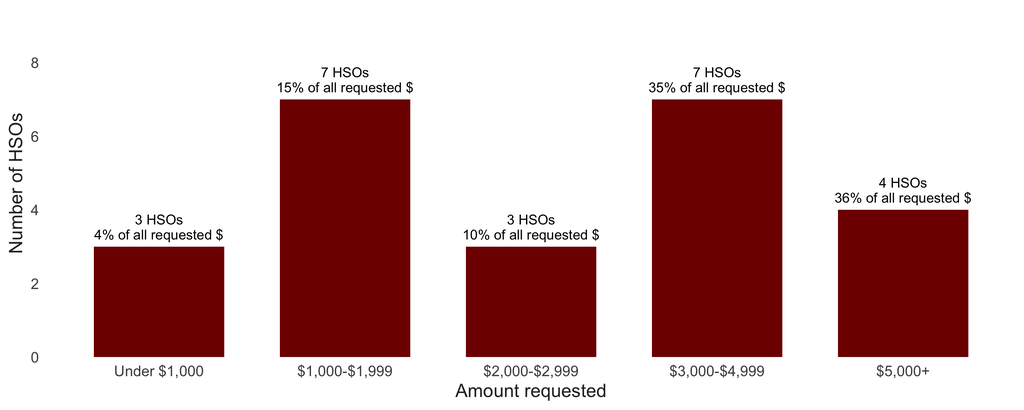

Each HSO’s request, eligible request and allocation, with the share of its request that was funded:

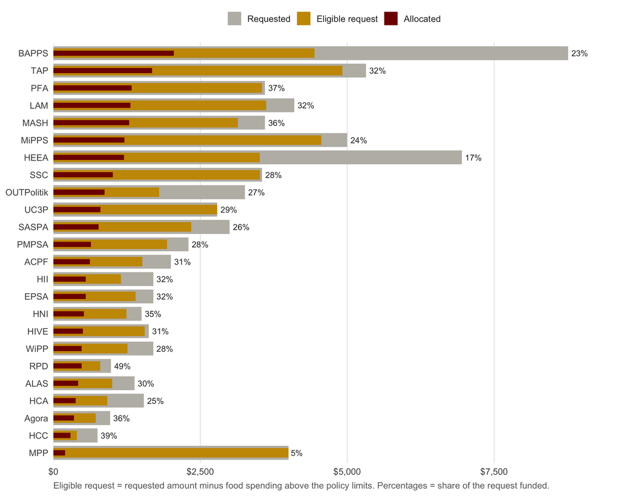

## What drove the allocations

Higher-scoring applications tended to receive a larger share of their eligible request. Smaller requests also score higher on this measure, because the equal flat share is a bigger part of them.

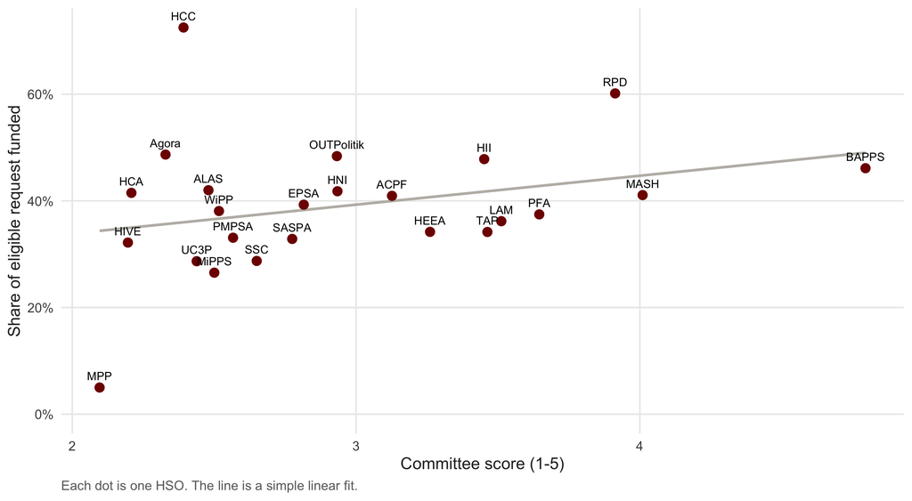

Rollover and outside funds lower an HSO’s automatic Financial Stewardship score. The chart shows each HSO’s balance relative to its request against the share it received.

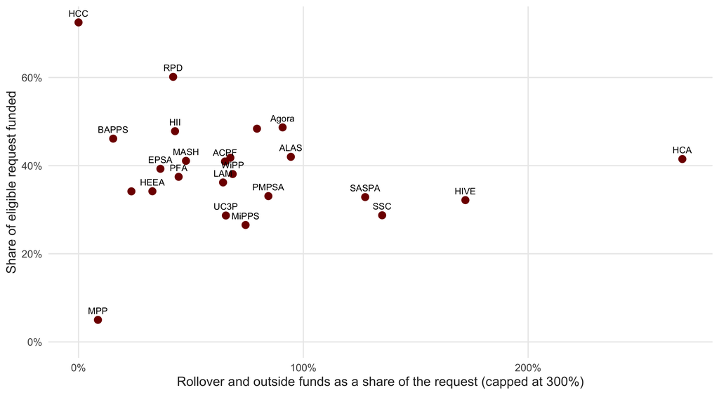

## Food and event rules

Of $53,673 in food requested across 97 events, $18,445 fell outside the limits above and was left out of eligible requests. HSOs can still spend on it, using rollover, RSO funds or sponsors.

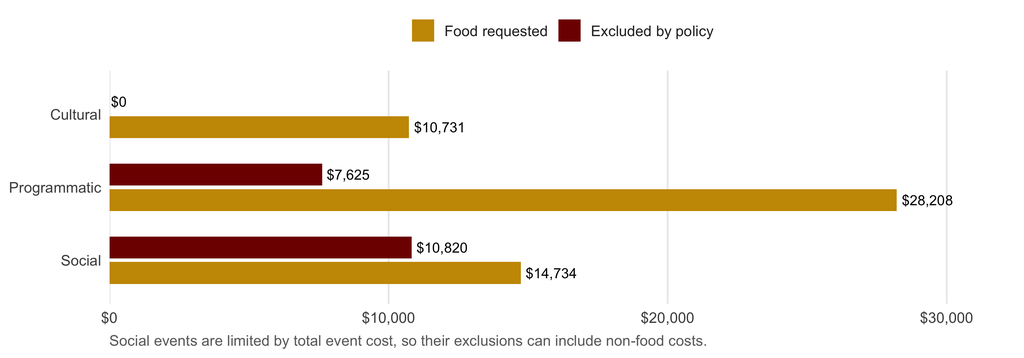

About half of all events (48 of 97) expect fewer than 50 people.

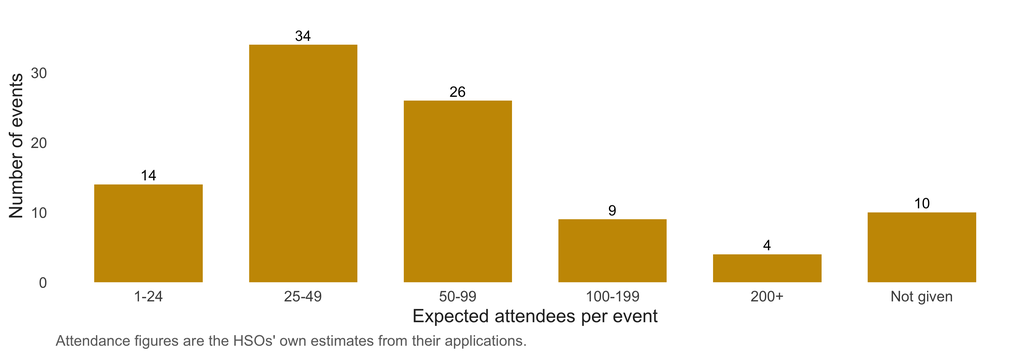

## Compared with past quarters

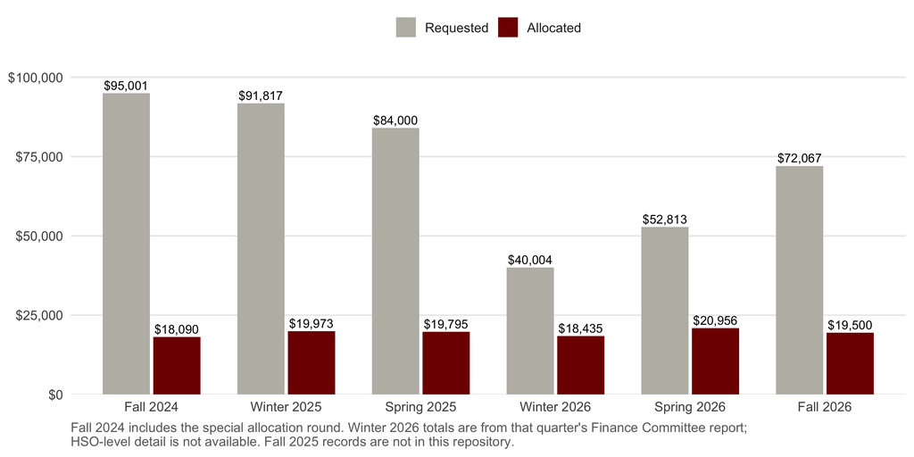

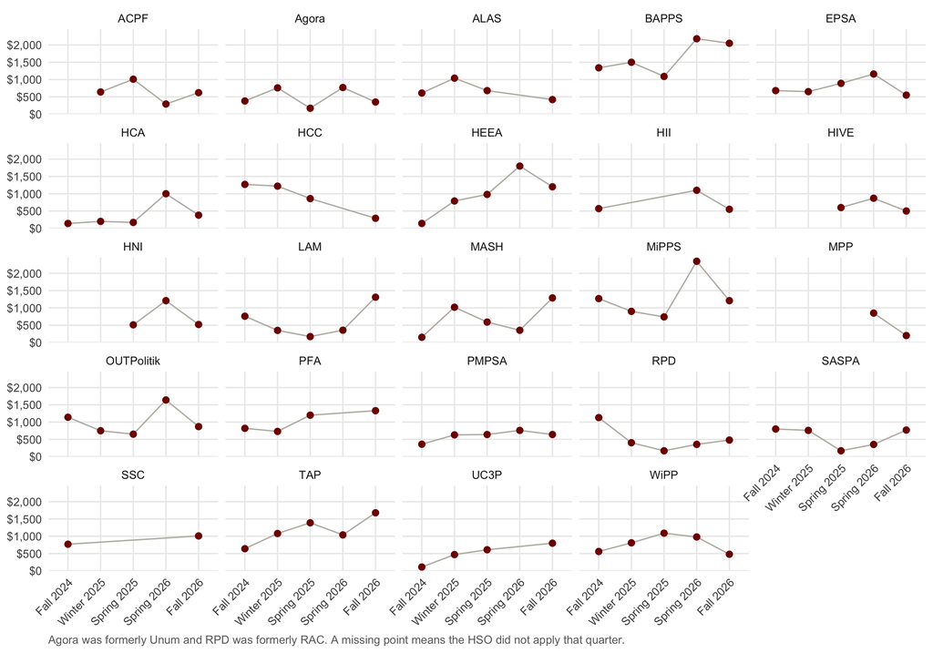

## What changed this quarter

Fall 2026 is the first quarter under a new, rules-based framework:

- **One published formula sets every allocation.** A flat share plus a flexible share based on score and eligible request. Any committee adjustment needs a written justification and is marked in the report.
- **Food limits are applied event by event**, with a written explanation for every exclusion.
- **There is no per-club cap.** The old $1,800 limit is gone; large allocations are flagged for committee review instead.
- **Every on-time applicant is scored on the same rubric**, including applications that were initially missed.
- **Earmarked funds are set aside.** Money restricted by a sponsor, donor or grant, committed under a signed contract, or saved for a specific, itemized event later in the academic year doesn’t count as rollover.
- **HSOs can respond.** They have 72 hours after receiving their event classifications to contest a classification, correct attendance, confirm co-hosts, update rollover or claim earmarked funds.

## Next steps

- Publish the food and event rules before applications open, so HSOs can budget around them.
- Collect actual attendance and spending after each quarter, so future reports compare plans to outcomes.

Sincerely,

**Ayan Sarkar**  
HSG Finance Committee Chair, 2026–27

## FAQs

#### Who reviews my HSO’s allocation application?

- **The HSG Finance Committee.** Five committee members each read every application and score the HSO from 1 to 5 in three areas: Financial Stewardship (30%), Collaboration & Inclusion (25%) and Impact (45%).
- **An automatic score** calculated from the application data (rollover, collaborations, expected attendance) counts as one more reviewer.
- **Reviewers recuse themselves** from HSOs they belong to.
- **Scoring is by HSO, not by event.** Every event is still read and classified so the food rules can be applied.
- **The HSG Executive Board** then reviews and votes to approve each HSO’s amount.
- **Full scoring criteria:** see the policy documents.

#### How is my allocation calculated?

- **Equal base share:** 25% of the budget is split equally among every HSO that applied on time ($208 each this quarter).
- **Shared pool:** the other 75% is split in proportion to **committee score × eligible request**.
- **Eligible request** is what the HSO asked for, minus food spending above the limits described in How funding works.
- **Upper limit and rounding:** no HSO gets more than its base share plus its eligible request, and amounts are rounded to the nearest $10.

#### Why did my HSO get less than it asked for?

- **Requests are bigger than the budget.** This quarter they totaled about 3.6 times the budget, so every HSO received part of its request.
- **The biggest factors** are food spending above the limits, a large rollover balance compared with the request, and few co-hosted events.
- **The committee score** sets each HSO’s share of the pool.

#### Will events for smaller communities, or events without co-hosts, score lower?

No. The automatic score is only one of six voices, and it can’t see everything. It counts attendance and co-hosts, but it can’t tell how much an event matters to the people it serves.

That’s what the five human reviewers are for. They score Impact by **who an event serves and how well it serves them**, not by size alone. Events for historically underrepresented communities, and policy topics that matter deeply to a smaller group, are valued as much as large events. Not every good event needs a co-host, and reviewers take that into account too.

#### Does my rollover count against me?

- **Yes, by default.** We use each HSO’s HarrisHub “Available” balance as rollover, and a large balance compared with the request lowers the Stewardship score.
- **Earmarked money is set aside** when the HSO documents it in its application: money restricted by a sponsor, donor or grant; money committed under a signed contract; or money saved for a specific, itemized event later in the same academic year, with its estimated cost and planned quarter.
- **General savings don’t count**, including money saved for unspecified “future events” or for after the academic year ends.

#### Who decides when my HSO gets its allocation?

The process involves HSO leaders, HSG and SEB (Student Engagement and Belonging):

1. HSG emails HSO leaders when applications open.
2. HSO leaders submit the application on HarrisHub by the deadline.
3. The Finance Committee classifies every event and sends each HSO its event classifications.
4. **HSOs have 72 hours** to contest a classification, correct attendance, confirm co-hosts, update rollover or claim earmarked funds. **This is the only chance to appeal.**
5. The Finance Committee scores applications and sets allocation amounts.
6. The HSG Executive Board reviews and votes to approve each amount.
7. HSOs are emailed their final allocation amount. Amounts can’t be changed after this point.
8. HSG sends SEB the approved amounts.
9. SEB adds the funds to each HSO’s HarrisHub account.

#### When does each quarter’s funding arrive?

| Quarter funded | Apply | Funds arrive |
| --- | --- | --- |
| Fall | By June of the previous academic year | By week 2 of Fall |
| Winter | About week 7 of Fall | Week 1 of Winter |
| Spring | About week 7 of Winter | Week 1 of Spring |

HSOs always apply the quarter before. For Fall, that means applying before summer break so funds are ready when the year starts. HSG emails exact dates each quarter.

#### What if we miss the deadline?

Late applications aren’t guaranteed a review. Any the committee accepts receive the equal base share only.

#### Is there a way to get my allocation sooner?

Not really. What helps is replying quickly to the Finance Committee’s email confirming your amount: the sooner HSOs respond, the sooner HSG can send the amounts to SEB.

#### What happens to money that isn’t allocated?

It goes to the Emergency Reserve, which is set aside for HSO use, including new HSOs that form during the year. This quarter, $500 went to the reserve.

#### Where can I see every HSO’s allocation?

Right here. The appendix lists what each HSO requested and received.

#### Who do I contact with questions?

Email the Finance Committee Chair, Ayan Sarkar.

## Meet the Finance Committee

| Name | Role |
| --- | --- |
| Ayan Sarkar | Finance Committee Chair, 2026–27 |
| Likhitha Chintareddy | Finance Committee Member |
| Tobias Oestreich | Finance Committee Member |
| Adlai Politi | Finance Committee Member |
| Mike Zhao | Finance Committee Member |

All five members review every application, and each recuses from HSOs they belong to.

## Resources

### HSO names

| Abbreviation | Organization |
| --- | --- |
| ACPF | Anti-Caste Policy Students Forum |
| Agora | Agora (formerly Unum) |
| ALAS | Association of Latinx Students for Social Justice |
| BAPPS | Black Action in Public Policy Studies |
| BEPP | Behavioral Science and Public Policy |
| EPSA | Education Policy Student Association |
| HCA | Harris Community Action |
| HCC | Harris Consulting Club |
| HEEA | Harris Energy & Environmental Association |
| HFG | Harris Finance Group |
| HII | Harris Impact Investing |
| HIVE | Harris Innovation & Venture Ecosystem |
| HNI | Health Nexus Initiative |
| IDPA | International Development Policy Association |
| LAM | Latin American Matters |
| MASH | Military Affiliated Students of Harris |
| MiPPS | Minorities in Public Policy Studies |
| MPP | Muslim Perspectives in Policy |
| OUTPolitik | OUTPolitik |
| PFA | Public Finance Association |
| PMPSA | Public Management and Policy Student Association |
| RPD | Rural Policy and Development (formerly RAC) |
| SASPA | South Asian Students Policy Association |
| SSC | South Side Civic |
| TAP | The African Perspective |
| UC3P | University of Chicago Public Policy Podcasts |
| WiPP | Women in Public Policy |

### Viewing your submitted requests

There are three ways to review requests your HSO has already submitted:

1. **Direct link:** open the [submitted requests outbox](https://uchicago.presence.io/admin/forms/responses/outbox).
2. **Through Forms:** go to the **Forms** section and select **Outbox** to see all submitted requests.
3. **Through Event Requests:** go to the **Events** section, select the **Request** tab, then click **Requires Action** to see requests that need review.

### Suggested Vendors

Please visit the direct payments page for more information on payments to vendors.

| Vendor | Food | Address | Phone |
| --- | --- | --- | --- |
| [Cedars Mediterranean Kitchen](http://www.cedarsmediterraneankitchen.com/) | Mediterranean, Lebanese | 1206 E 53rd St, Chicago, IL 60615 | 773-324-6227 |
| [Maravilla’s](http://chicago.menupages.com/restaurants/maravillas/) | Mexican | 5506 S Lake Park Ave, Chicago, IL 60615 | 773-955-7680 |
| [Medici on 57th](http://www.medici57.com/) | Italian-American and other specialties; house account available | 1327 E 57th St, Chicago, IL 60637 | 773-667-7394 |
| [Good Earth Catering](http://www.goodearthchicago.com) | Catering | 3931 S Leavitt St, Chicago, IL 60609 | 773-893-0093 |
| [Giordano’s](https://www.giordanos.com) | Chicago-style pizza | 5311 S Blackstone Ave, Chicago, IL 60615 | 773-947-0200 |
| [Rajun Cajun](https://www.rajunrestaurant.com) | American, Indian, Southern | 1459 E 53rd St, Chicago, IL 60615 | 773-955-1145 |
| [Pho 55](https://www.pho55.com) | Vietnamese | 1611 E 55th St, Chicago, IL 60615 | 773-363-1515 |
| [The Sit Down Café & Sushi Bar](https://www.thesitdowncafe.com) | Sushi, sandwiches, pizza, Italian | 1312 E 53rd St, Chicago, IL 60615 | 773-324-3700 |
| [The Snail Thai Cuisine](https://www.snailthai.com) | Thai | 1649 E 55th St, Chicago, IL 60615 | 773-667-5423 |
| [Thai 55 Restaurant](https://www.thai55restaurant.com) | Thai | 1607 E 55th St, Chicago, IL 60615 | 773-363-7119 |
| [Pizza Capri](https://www.pizzacapri.com) | Pizza, Italian | 1501 E 53rd St, Chicago, IL 60615 | 773-324-7777 |
| Mellow Yellow | American, burgers | 1508 E 53rd St, Chicago, IL 60615 | 773-667-2000 |
| [Pockets](http://www.pocketsonline.com/) | Sandwiches, healthy food | 1307 E 53rd St, Chicago, IL 60615 | 773-667-1313 |
| [A10 Hyde Park](https://www.a10hydepark.com) | Italian, seafood | 1642 E 53rd St, Chicago, IL 60615 | 773-288-1010 |
| [The Nile Restaurant](http://www.thenilerestaurant.net/) | Middle Eastern | 1162 E 55th St, Chicago, IL 60615 | 773-324-9499 |
| [Noodles Etc.](http://noodlesetc.com/) | Thai | 1333 E 57th St, Chicago, IL 60637 | 773-684-2801 |
| [Siam Thai Cuisine](http://siamthaicuisinechicago.com) | Thai | 1639-43 E 55th St, Chicago, IL 60615 | 773-324-9296 |
| [Kikuya Japanese Restaurant](https://www.kikuyaonline.com/) | Japanese, sushi | 1601 E 55th St, Chicago, IL 60615 | 773-667-3727 |
| [Piccolo Mondo Café](http://www.piccolomondo.us/) | Italian, desserts, bakery | 1642 E 56th St, Chicago, IL 60637 | 773-643-1106 |
| [Shinju Sushi](https://www.shinjusushichicago.com/) | Sushi, Japanese | 1375 E 53rd St, Chicago, IL 60615 | 773-966-6669 |
| [Porkchop](http://www.chicagoporkchop.com/) | BBQ, American, Southern | 1516 E Harper Ct, Chicago, IL 60615 | 773-493-9333 |
| [Plein Air Café](http://www.pleinaircafe.co/) | European, sandwiches, coffee and tea | 5751 S Woodlawn Ave, Chicago, IL 60637 | 773-966-7531 |
| [La Petite Folie](http://lapetitefolie.com/) | French | 1504 E 55th St, Chicago, IL 60615 | 773-493-1394 |
| [Nathan’s Taste of Jamaica](http://www.nathanschicago.net/) | Jamaican, seafood | 1372 E 53rd St, Chicago, IL 60615 | 773-288-5353 |
| [Café 53](http://www.cafe-53.com/) | Sandwiches, desserts, café | 1369 E 53rd St, Chicago, IL 60615 | 773-493-1000 |
| [Yusho](http://yushohydepark.com/) | Japanese | 1301 E 53rd St, Chicago, IL 60615 | 773-643-1652 |

## Policy documents

The committee’s Fall 2026 policy documents, to read online or download:

- **Allocation Policy and Methodology:** the full rules, formulas and parameters. [Read online](https://github.com/A-Sarkar18/hsg-finance-transparency/blob/main/policy/Fall%202026%20Allocation%20Policy%20and%20Methodology.md) · [Download (Word)](https://github.com/A-Sarkar18/hsg-finance-transparency/blob/main/policy/Fall%202026%20Allocation%20Policy%20and%20Methodology.docx?raw=true)
- **One-Page Guide for HSOs:** how funding works, on one page. [Read online](https://github.com/A-Sarkar18/hsg-finance-transparency/blob/main/policy/Fall%202026%20Funding%20-%20One-Page%20Guide%20for%20HSOs.md) · [Download (Word)](https://github.com/A-Sarkar18/hsg-finance-transparency/blob/main/policy/Fall%202026%20Funding%20-%20One-Page%20Guide%20for%20HSOs.docx?raw=true)
- **Scoring README and Reviewer Manual:** how reviewers score applications. [Read online](https://github.com/A-Sarkar18/hsg-finance-transparency/blob/main/policy/Fall%202026%20Scoring%20README%20and%20Reviewer%20Manual.md) · [Download (Word)](https://github.com/A-Sarkar18/hsg-finance-transparency/blob/main/policy/Fall%202026%20Scoring%20README%20and%20Reviewer%20Manual.docx?raw=true)

## Appendix: allocations by HSO

| HSO | Requested | Rollover + outside | Eligible request | Committee score | Flat | Flexible | Allocated | % of eligible | Note |
| --- | --- | --- | --- | --- | --- | --- | --- | --- | --- |
| BAPPS | $8,758 | $1,350 | $4,444 | 4.80 | $208 | $1,839 | $2,050 | 46% |  |
| TAP | $5,320 | $1,251 | $4,917 | 3.46 | $208 | $1,469 | $1,680 | 34% |  |
| PFA | $3,600 | $1,603 | $3,550 | 3.65 | $208 | $1,117 | $1,330 | 37% |  |
| LAM | $4,100 | $2,636 | $3,620 | 3.51 | $208 | $1,097 | $1,310 | 36% |  |
| MASH | $3,600 | $1,721 | $3,140 | 4.01 | $208 | $1,087 | $1,290 | 41% |  |
| MiPPS | $5,000 | $3,716 | $4,560 | 2.50 | $208 | $1,002 | $1,210 | 27% |  |
| HEEA | $6,950 | $2,284 | $3,510 | 3.26 | $208 | $988 | $1,200 | 34% |  |
| SSC | $3,550 | $4,795 | $3,515 | 2.65 | $208 | $804 | $1,010 | 29% |  |
| OUTPolitik | $3,260 | $2,588 | $1,798 | 2.93 | $208 | $455 | $870 | 48% | Committee adjustment: additional funding for midterm-election programming. |
| UC3P | $2,789 | $1,828 | $2,789 | 2.44 | $208 | $587 | $800 | 29% |  |
| SASPA | $3,000 | $3,825 | $2,343 | 2.78 | $208 | $561 | $770 | 33% |  |
| PMPSA | $2,300 | $1,942 | $1,934 | 2.57 | $208 | $428 | $640 | 33% |  |
| ACPF | $2,000 | $1,303 | $1,514 | 3.13 | $208 | $409 | $620 | 41% |  |
| EPSA | $1,700 | $619 | $1,400 | 2.82 | $208 | $340 | $550 | 39% |  |
| HII | $1,700 | $730 | $1,150 | 3.45 | $208 | $343 | $550 | 48% |  |
| HNI | $1,500 | $1,013 | $1,244 | 2.93 | $208 | $315 | $520 | 42% |  |
| HIVE | $1,625 | $2,796 | $1,554 | 2.20 | $208 | $295 | $500 | 32% |  |
| RPD | $980 | $413 | $798 | 3.91 | $208 | $269 | $480 | 60% |  |
| WiPP | $1,700 | $1,166 | $1,260 | 2.52 | $208 | $274 | $480 | 38% |  |
| ALAS | $1,380 | $1,303 | $1,000 | 2.48 | $208 | $214 | $420 | 42% |  |
| HCA | $1,540 | $4,136 | $916 | 2.21 | $208 | $175 | $380 | 41% |  |
| Agora | $965 | $876 | $719 | 2.33 | $208 | $144 | $350 | 49% |  |
| HCC | $750 | $0 | $400 | 2.39 | $208 | $83 | $290 | 72% |  |
| MPP | $4,000 | $346 | $4,000 | 2.10 | $208 | $724 | $200 | 5% | Committee adjustment. Can be revisited once an itemized event budget is submitted. |

Data and code: github.com/A-Sarkar18/hsg-finance-transparency. Adapted from the [HSG Finance Committee transparency report](https://github.com/notkarenyi/hsg-fc) by Karen Yi.